# trabajo_ap_inf

Ines Dominguez

```r
library(readxl)
base_datos_ines <- read_excel(path = "base datos ines.xls")
```

Para este trabajo, contamos con una base de datos de objetos líticos realizados en obsidiana de Mesoamérica (obtenida de Comparative Archaeology Database). Los objetos se dividen en lascas y láminas, y la base de datos cuenta con variables que nos aportan datos sobre la anchura, la longitud, el grosor y el peso de las piezas. La pregunta a la que tenemos que responder es: ¿en base a los parámetros arqueométricos, podemos deducir si una pieza se trata de una lasca o una lámina?.

Para responder esta pregunta, mi compañero David Villalobo y yo usaremos cada uno una base de datos distinta, para finalmente comprobar y comparar nuestros resultados. Para saber si las variables influyen a la hora de que sea un tipo de objeto u otro, usaremos modelos logísticos simples y múltiples, e intentaremos buscar diferentes soluciones cuando se den dificultades en la interpretación de los resultados, ya que ambos data frame cuenta con pocos datos, debido a moltivos que se explicarán a continuación (con la diferencia que de mi base de datos es incluso más escueta).

Primero debemos cargar la librería ‘ggplot2’ para poder trabajar con los datos. Posteriormente, cargaremos la base de datos descargada desde ‘Comparative Archaeology Database’. La base de datos ha sido modificada anteriormente desde Excel, para que contuviera exclusivamente las variables que nos interesan. También se han eliminado datos que contenían el valor ‘NA’ (Not Available), para evitar posibles fallos a la hora de realizar nuestros análisis, y además, para poder trabajar mejor a la hora de realizar los códigos, hemos renombrado las columnas desde Excel.

Para cargar la base de datos, lo haremos desde ‘Environment’, e importaremos la base de datos, ya modificada, desde Excel.

```r
library(ggplot2)
```

Además, vamos a recodificar la columna ‘Tipo’ para tener los datos en lenguaje adecuado para trabajar con una regresión logística, es decir, cambiaremos los términos ‘blade’ y ‘flake’ con 0 y 1. Para ello, accederemos a la columna ‘Tipo’ de nuestra base de datos con el símbolo ‘$’.

La función ‘ifelse’ sirve para evaluar una condición y retornar diferentes valores dependiendo de si la condición es verdadera o falsa. En este caso, la condición es ’base_datos_ines$Tipo==“Blade”, que verifica si los valores en la columna “Tipo” son iguales a “Blade”. Si la condición es verdadera, se asigna el valor 1, y si es falsa, se asigna el valor 0. Esto crea un nuevo vector con los valores 1 y 0 correspondientes a cada fila en la columna “Tipo”.

La función ‘as.factor’ se utiliza para convertir el vector resultante en un factor, una estructura de datos que representa variables categóricas. Estamos creando una nueva columna llamada ‘Tipo_f’.

```r
base_datos_ines$Tipo_f <- as.factor(ifelse(base_datos_ines$Tipo=="Blade",1,0))
```

A continuación, crearemos gráficos de distribución según las variables para examinar la forma en que los valores de una variable se distribuyen en función de otra variable o grupo. Así podremos identificar patrones o identificar valores atípicos.

Para ello usaremos la función ‘ggplot’ de la biblioteca ‘ggplot2’. Indicamos ‘base_datos_ines’ como nuestra data frame y usamos la función ‘aes’ para definir cómo se asignarán las variables a los diferentes elementos del gráfico. En este caso, “Longitud” lo asignaremos al eje x, “Anchura” al eje y, y “Tipo” se asigna al color de los puntos.

La función ‘geom_point’ agrega puntos al gráfico para representar los valores de las variables. Así, podemos ver representadas los valores 0 (flake) en verde, y 1 (blade) en naranja.

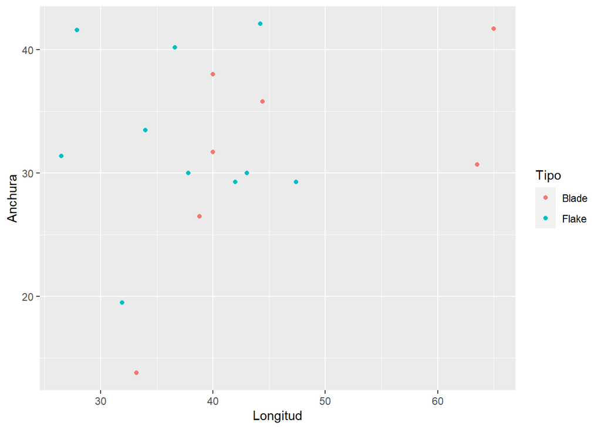

```r
ggplot(base_datos_ines, aes(x=Longitud, y=Anchura, color = Tipo)) + geom_point()
```

Este tipo de gráficos nos ayuda a ver cómo se relacionan las variables Longitud y Anchura según los datos de nuestro data frame. Vemos que hay una tendencia de los puntos a agruparse en la esquina superior izquierda, lo que indica que todas las piezas de nuestra base de datos se mueven en un márgen típico de unos 30-40 cm de anchura y unos 40-45 cm de longitud aproximadamente.

Además, vemos que hay una ligera diferencia, típica en la arqueología prehistórica, entre flake (lasca) y blade (lámina). Podemos observar, aunque ligeramente, que las láminas (naranja) tienen una tendencia a ser más largas, pues hay una tendencia en el gráfico hacia la derecha. En cambio las lascas (verde), suelen ser más cortas, puesto que ocupan sobre todo el lado izquierdo del gráfico. Cabe destacar 2 casos inusuales de láminas, mucho más largas que el resto, que se encuentran en el lateral derecho, y un caso que es mucho más pequeño que los demás, tanto en longitud como en anchura (esquina inferior izquierda).

Ahora, podemos realizar el mismo gráfico pero esta vez usando las variables Grosor y Peso.

```
## Warning: Removed 3 rows containing missing values (`geom_point()`).
```

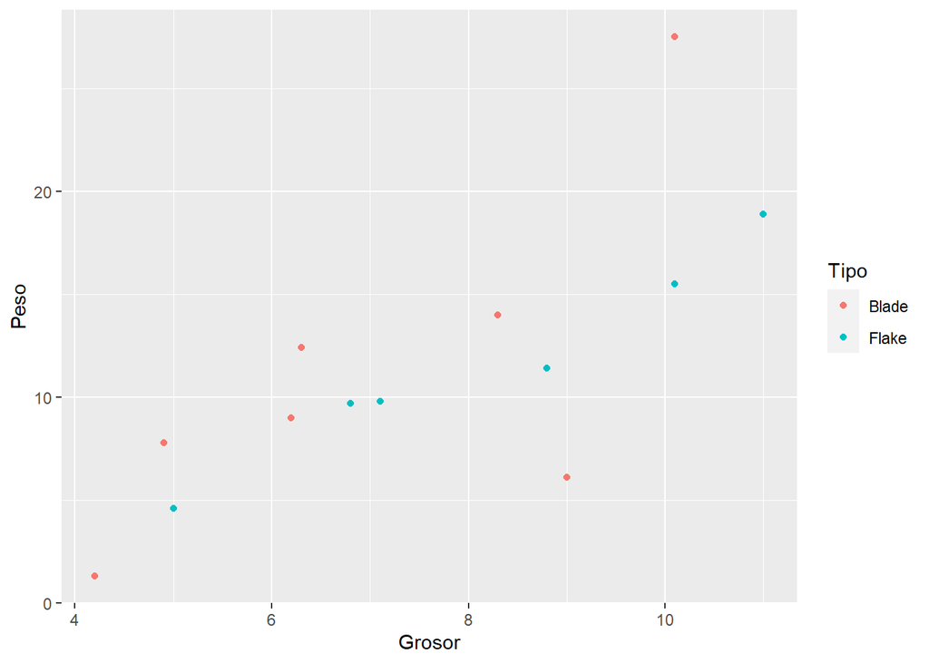

```r
ggplot(base_datos_ines, aes(x=Grosor, y=Peso, color = Tipo)) + geom_point()
```

Gracias a este gráfico y su tendencia diagonal, podemos observar que, mientras más gruesa sea la pieza, más va a pesar, siendo el caso de la esquina inferior izquierda la pieza más pequeña y con menos peso (lámina), y la de la esquina superior derecha la más pesada (lámina). También podemos observar una ligera tendencia de las lascas a ser más gruesas que las láminas, pero realmente tenemos muy pocos datos para que los resultados sean algo significativo.

Cabe destacar que arriba del gráfico nos salta un aviso. Este aviso es debido a que en la variable Peso nos faltan 3 valores, los cuales no aparecían en la base de datos original.

Ahora realizaremos modelos de regresión logística con la función ‘glm’ y obtendremos un resumen de los resultados con la función ‘summary’. El argumento ‘Tipo_f ~ Anchura’ especifica la fórmula del modelo, donde “Tipo_f” es la variable dependiente y “Anchura” es la variable independiente. El argumento ‘base_datos_ines’ especifica el conjunto de datos utilizado para el ajuste del modelo. El argumento family = “binomial” indica que se está ajustando un modelo de regresión logística con una distribución binomial.

Con estos modelos podremos ver en qué medida afectan las distintas variables a la hora de si un instrumento es una lasca o una lámina.

```r
summary(glm(Tipo_f ~ Anchura , base_datos_ines, family ="binomial"))
```

```
##
## Call:
## glm(formula = Tipo_f ~ Anchura, family = "binomial", data = base_datos_ines)
##
## Deviance Residuals:
##     Min       1Q   Median       3Q      Max
## -1.1693  -1.0514  -0.9284   1.3172   1.4500
##
## Coefficients:
##             Estimate Std. Error z value Pr(>|z|)
## (Intercept)  0.51000    2.16542   0.236    0.814
## Anchura     -0.02713    0.06619  -0.410    0.682
##
## (Dispersion parameter for binomial family taken to be 1)
##
##     Null deviance: 23.035  on 16  degrees of freedom
## Residual deviance: 22.865  on 15  degrees of freedom
## AIC: 26.865
##
## Number of Fisher Scoring iterations: 4
```

```r
summary(glm(Tipo_f ~ Grosor, base_datos_ines, family ="binomial"))
```

```
##
## Call:
## glm(formula = Tipo_f ~ Grosor, family = "binomial", data = base_datos_ines)
##
## Deviance Residuals:
##     Min       1Q   Median       3Q      Max
## -1.3216  -0.9345  -0.7680   1.1763   1.6522
##
## Coefficients:
##             Estimate Std. Error z value Pr(>|z|)
## (Intercept)   1.7079     2.0557   0.831    0.406
## Grosor       -0.2750     0.2682  -1.026    0.305
##
## (Dispersion parameter for binomial family taken to be 1)
##
##     Null deviance: 23.035  on 16  degrees of freedom
## Residual deviance: 21.915  on 15  degrees of freedom
## AIC: 25.915
##
## Number of Fisher Scoring iterations: 4
```

```r
summary(glm(Tipo_f ~ Longitud, base_datos_ines, family ="binomial"))
```

```
##
## Call:
## glm(formula = Tipo_f ~ Longitud, family = "binomial", data = base_datos_ines)
##
## Deviance Residuals:
##     Min       1Q   Median       3Q      Max
## -1.3376  -0.8925  -0.5448   1.1646   1.7261
##
## Coefficients:
##             Estimate Std. Error z value Pr(>|z|)
## (Intercept) -4.98308    2.98066  -1.672   0.0946 .
## Longitud     0.11291    0.07248   1.558   0.1192
## ---
## Signif. codes:  0 '***' 0.001 '**' 0.01 '*' 0.05 '.' 0.1 ' ' 1
##
## (Dispersion parameter for binomial family taken to be 1)
##
##     Null deviance: 23.035  on 16  degrees of freedom
## Residual deviance: 19.289  on 15  degrees of freedom
## AIC: 23.289
##
## Number of Fisher Scoring iterations: 4
```

```r
summary(glm(Tipo_f ~ Peso, base_datos_ines, family ="binomial"))
```

```
##
## Call:
## glm(formula = Tipo_f ~ Peso, family = "binomial", data = base_datos_ines)
##
## Deviance Residuals:
##      Min        1Q    Median        3Q       Max
## -1.21199  -1.17731  -0.00641   1.16383   1.26011
##
## Coefficients:
##             Estimate Std. Error z value Pr(>|z|)
## (Intercept)  0.13589    1.11787   0.122    0.903
## Peso        -0.01194    0.08626  -0.138    0.890
##
## (Dispersion parameter for binomial family taken to be 1)
##
##     Null deviance: 19.408  on 13  degrees of freedom
## Residual deviance: 19.389  on 12  degrees of freedom
##   (3 observations deleted due to missingness)
## AIC: 23.389
##
## Number of Fisher Scoring iterations: 3
```

Si nos fijamos en la columna Pr(>|z|), de los valores p, vemos que en ningún modelo nos dan resultados significativos. Un valor p bajo (inferior a 0.05) sugiere que hay una relación estadísticamente significativa entre la variable predictora y la variable respuesta, lo cual no es nuestro caso.

Podríamos interpretar estos resultados como que no existe una relacion directa entre las variables y el tipo de instrumento, pero realmente es debido a la escasez de datos con la que contamos.

A continuación, realizaremos otra vez modelos de regresión logística, pero esta vez múltiples, es decir, con varias variables, con la misma intención que en el apartado anterior: ver si la combinación de varias variables es significativa a la hora de ser lámina o lasca.

Para ello volveremos a usar la función ‘glm’. La fórmula ‘Tipo_f ~ Anchura + Longitud especifica que “Tipo_f” es la variable dependiente y “Anchura” y “Longitud” son las variables independientes. Indicaremos el conjunto de datos que vamos a usar con ’base_datos_ines’ y volveremos a indicar la distribución binomial con family = “binomial”. Con ‘summary’ generaremos un resumen de los resultados. Las variables con más sentido arqueológico para combinar en el caso de lascas y láminas son las de Anchura y Longitud. Vamos a ver en qué medida influyen estas dos variables predictoras en la variable respuesta ‘Tipo’:

```r
summary(glm(Tipo_f ~ Anchura + Longitud , base_datos_ines, family ="binomial"))
```

```
##
## Call:
## glm(formula = Tipo_f ~ Anchura + Longitud, family = "binomial",
##     data = base_datos_ines)
##
## Deviance Residuals:
##     Min       1Q   Median       3Q      Max
## -1.5144  -0.9016  -0.4062   1.1405   1.6587
##
## Coefficients:
##             Estimate Std. Error z value Pr(>|z|)
## (Intercept) -3.49655    3.39587  -1.030    0.303
## Anchura     -0.08918    0.08419  -1.059    0.290
## Longitud     0.14502    0.08916   1.627    0.104
##
## (Dispersion parameter for binomial family taken to be 1)
##
##     Null deviance: 23.035  on 16  degrees of freedom
## Residual deviance: 18.078  on 14  degrees of freedom
## AIC: 24.078
##
## Number of Fisher Scoring iterations: 5
```

Al realizar este modelo de regresión logística vemos que los coeficientes estimados son muy bajos, y los valores p son superiores a 0.05, lo que significa que, en principio, la significancia estadística de estos coeficientes es baja. Aunque realmente esto es debido a la poca cantidad de piezas que tiene la base de datos debido a la criba de datos que se realizó al inicio.

Cabe destacar que la variable Longitud sería de todas la que más significancia tiene (aunque sigue siendo muy poca), puesto que el coeficiente estimado es positivo en vez de negativo, y el valor p es el que más se acerca a 0.05.

Probamos ahora a realizarla con las mismas variables, esta vez añadiendo la de Grosor para comprobar si influye en algo:

```r
summary(glm(Tipo_f ~ Anchura + Longitud + Grosor, base_datos_ines, family ="binomial"))
```

```
##
## Call:
## glm(formula = Tipo_f ~ Anchura + Longitud + Grosor, family = "binomial",
##     data = base_datos_ines)
##
## Deviance Residuals:
##     Min       1Q   Median       3Q      Max
## -1.8133  -0.6610  -0.1901   0.4637   2.0793
##
## Coefficients:
##             Estimate Std. Error z value Pr(>|z|)
## (Intercept) -2.31591    3.53919  -0.654   0.5129
## Anchura     -0.01517    0.10516  -0.144   0.8853
## Longitud     0.20333    0.10449   1.946   0.0517 .
## Grosor      -0.80117    0.48804  -1.642   0.1007
## ---
## Signif. codes:  0 '***' 0.001 '**' 0.01 '*' 0.05 '.' 0.1 ' ' 1
##
## (Dispersion parameter for binomial family taken to be 1)
##
##     Null deviance: 23.035  on 16  degrees of freedom
## Residual deviance: 14.383  on 13  degrees of freedom
## AIC: 22.383
##
## Number of Fisher Scoring iterations: 5
```

Una vez más comprobamos los mismos resultados: no dan resultados significativos a excepción de Longitud, que es la variable que más se acercaría a dar una significancia sobre ‘Tipo’ (blade o flake).

Haciendo varias pruebas con las posibles combinaciones de todas las variables, vemos que la combinación Longitud + Grosor es la que da más significancia y por tanto, el modelo que mejor explicaría los datos. Aquí, la variable Longitud es la que nos ha dado un valor p significativo (0.04).

```r
summary(glm(Tipo_f ~ Longitud + Grosor, base_datos_ines, family ="binomial"))
```

```
##
## Call:
## glm(formula = Tipo_f ~ Longitud + Grosor, family = "binomial",
##     data = base_datos_ines)
##
## Deviance Residuals:
##     Min       1Q   Median       3Q      Max
## -1.7992  -0.6828  -0.2076   0.4613   2.1231
##
## Coefficients:
##             Estimate Std. Error z value Pr(>|z|)
## (Intercept)  -2.4555     3.3602  -0.731   0.4649
## Longitud      0.2000     0.1006   1.988   0.0468 *
## Grosor       -0.8275     0.4559  -1.815   0.0695 .
## ---
## Signif. codes:  0 '***' 0.001 '**' 0.01 '*' 0.05 '.' 0.1 ' ' 1
##
## (Dispersion parameter for binomial family taken to be 1)
##
##     Null deviance: 23.035  on 16  degrees of freedom
## Residual deviance: 14.404  on 14  degrees of freedom
## AIC: 20.404
##
## Number of Fisher Scoring iterations: 5
```

Probamos ahora a realizar el modelo de regresión logística con todas las variables a la vez:

```r
summary(glm(Tipo_f ~ Anchura + Longitud + Grosor + Peso, base_datos_ines, family ="binomial"))
```

```
##
## Call:
## glm(formula = Tipo_f ~ Anchura + Longitud + Grosor + Peso, family = "binomial",
##     data = base_datos_ines)
##
## Deviance Residuals:
##      Min        1Q    Median        3Q       Max
## -1.99772  -0.72828   0.02729   0.68017   1.64750
##
## Coefficients:
##              Estimate Std. Error z value Pr(>|z|)
## (Intercept) -3.080265   9.077726  -0.339    0.734
## Anchura     -0.007368   0.192203  -0.038    0.969
## Longitud     0.229032   0.187070   1.224    0.221
## Grosor      -0.651864   0.521819  -1.249    0.212
## Peso        -0.131750   0.397120  -0.332    0.740
##
## (Dispersion parameter for binomial family taken to be 1)
##
##     Null deviance: 19.408  on 13  degrees of freedom
## Residual deviance: 12.728  on  9  degrees of freedom
##   (3 observations deleted due to missingness)
## AIC: 22.728
##
## Number of Fisher Scoring iterations: 5
```

En realidad lo que sucede aquí es que, en este data frame, tenemos dos casos de láminas que son inusualmente anchos y largos, mucho más grandes que los demás (son los dos casos inusuales que se comentaron en el primer gráfico de distribución). En un análisis estadístico profesional se eliminarían estos dos valores por considerarse ‘outliers’, pudiendo afectar al análisis estadístico y a la interpretación de los resultados, pero, al contar con tan pocos datos en este data frame, es más conveniente dejarlos e interpretar los resultados que nos vayan saliendo.

Aun así, queremos seguir probando modelos logísticos con las variables Anchura y Longitud porque son las que tienen más sentido arqueológico. Pero esta vez lo haremos de forma distinta: creamos una nueva variable (proporción longitud/anchura), y con esta variable, volveremos a realizar modelos logísticos simples y después múltiples.

Para ello, llamaremos a la nueva variable ‘long_anch’. Para hacer referencia a la columna dentro de nuestra base de datos ‘base_datos_ines’ usaremos el símbolo $. Con ’/’dividiremos el valor de la columna Longitud entre el valor de la columna Anchura. Así, vemos representada la proporción entre la longitud y la anchura para cada fila de nuestra base de datos.

```r
base_datos_ines$long_anch <- base_datos_ines$Longitud/base_datos_ines$Anchura
```

Una vez tenemos creada la nueva variable, vamos a realizar primero el modelo logístico simple de la misma forma que anteriormente:

```r
summary(glm(Tipo_f ~ long_anch, base_datos_ines, family ="binomial"))
```

```
##
## Call:
## glm(formula = Tipo_f ~ long_anch, family = "binomial", data = base_datos_ines)
##
## Deviance Residuals:
##     Min       1Q   Median       3Q      Max
## -1.3419  -0.9251  -0.5685   1.1052   1.7027
##
## Coefficients:
##             Estimate Std. Error z value Pr(>|z|)
## (Intercept)   -3.999      2.295  -1.742   0.0814 .
## long_anch      2.676      1.642   1.630   0.1031
## ---
## Signif. codes:  0 '***' 0.001 '**' 0.01 '*' 0.05 '.' 0.1 ' ' 1
##
## (Dispersion parameter for binomial family taken to be 1)
##
##     Null deviance: 23.035  on 16  degrees of freedom
## Residual deviance: 19.224  on 15  degrees of freedom
## AIC: 23.224
##
## Number of Fisher Scoring iterations: 4
```

Ahora, vamos a realizar modelos logísticos múltiples usando esta nueva variable ‘long_anch’ con las otras dos variables que nos quedan (primero con Grosor y luego con Peso)

```r
summary(glm(Tipo_f ~ long_anch + Grosor, base_datos_ines, family ="binomial"))
```

```
##
## Call:
## glm(formula = Tipo_f ~ long_anch + Grosor, family = "binomial",
##     data = base_datos_ines)
##
## Deviance Residuals:
##     Min       1Q   Median       3Q      Max
## -1.5570  -0.8505  -0.4257   1.1915   1.5598
##
## Coefficients:
##             Estimate Std. Error z value Pr(>|z|)
## (Intercept)  -2.1896     3.2402  -0.676    0.499
## long_anch     2.6723     1.7517   1.526    0.127
## Grosor       -0.2363     0.3178  -0.743    0.457
##
## (Dispersion parameter for binomial family taken to be 1)
##
##     Null deviance: 23.035  on 16  degrees of freedom
## Residual deviance: 18.644  on 14  degrees of freedom
## AIC: 24.644
##
## Number of Fisher Scoring iterations: 4
```

```r
summary(glm(Tipo_f ~ long_anch + Peso, base_datos_ines, family ="binomial"))
```

```
##
## Call:
## glm(formula = Tipo_f ~ long_anch + Peso, family = "binomial",
##     data = base_datos_ines)
##
## Deviance Residuals:
##     Min       1Q   Median       3Q      Max
## -1.5225  -0.8243  -0.1600   1.0117   1.5672
##
## Coefficients:
##              Estimate Std. Error z value Pr(>|z|)
## (Intercept) -4.087020   2.897607  -1.410    0.158
## long_anch    2.973338   1.972326   1.508    0.132
## Peso         0.006108   0.103143   0.059    0.953
##
## (Dispersion parameter for binomial family taken to be 1)
##
##     Null deviance: 19.408  on 13  degrees of freedom
## Residual deviance: 15.937  on 11  degrees of freedom
##   (3 observations deleted due to missingness)
## AIC: 21.937
##
## Number of Fisher Scoring iterations: 4
```

De nuevo, no nos sale nada significativo, posiblemente debido a la escasez de datos en nuestro dataframe.

Pero podemos buscar una última solución: intentar determinar cuál de los dos tipos es más cuadrado y cuál es más rectangular. Para ello, hemos de calcular la media del valor en cada grupo.

Para ello, usaremos la función ‘mean’, que nos permite calcular la media de los valores. Indicaremos la columna correspondiente (long_anch) dentro de nuestro data frame con ‘$'. Con "[dat$Tipo==“Flake”] le decimos al programa que, dentro de la columna Tipo, seleccione solo los valores ’Flake’.

```r
mean(base_datos_ines$long_anch [base_datos_ines$Tipo=="Flake"])
```

```
## [1] 1.18703
```

```r
mean(base_datos_ines$long_anch [base_datos_ines$Tipo=="Blade"])
```

```
## [1] 1.578827
```

Por otra parte, en Blade (lámina), vemos que el valor que nos da está más alejado del 1, por lo cual los valores de longitud y anchura son ligeramente más distintos, lo que sugiere que las láminas tienden a ser más rectangulares.

Partiendo de la base de que mi compañero contaba con más datos en su data frame, hemos observado que en comparación con los resultados de mi compañero David, en los resultados de los modelos logísticos múltiples, vemos una similitud: siempre que se hagan comparaciones con las diferentes variables, la única que da una significancia es la de Longitud, aunque en su caso, a diferencia del mío, el valor p de Longitud nunca llega a ser inferior de 0.05. Además, igual que en mi caso, los otros valores no aportan relaciones significativas a la hora de detrminar si el objeto es una lasca o una lámina.

Una diferencia entre nuestros dos casos es que en el caso de David, al hacer el modelo logístico con la variable de la proporción Longitud-Anchura, sí sale una significancia, aunque de nuevo bastante baja. Probablemente esto es debido a que David contaba con una base de datos más amplia que yo.

Bibliografía:

https://www.cadb.pitt.edu/

Brage Escalona, M. (2020). Análisis de datos categóricos: regresión logística y multinomial.